# Understanding NBA Foul Calls with Python

## PyData NYC • Nov 27, 2017 • [@AustinRochford](https://twitter.com/AustinRochford)

## About Me

[figure not shown]

### Principal Data Scientist @ [Monetate Labs](http://www.monetate.com/) • PyMC3 contributor

### [@AustinRochford](https://twitter.com/AustinRochford) • austinrochford.com • github.com/AustinRochford

### austin.rochford@gmail.com • arochford@monetate.com

## About this Talk

# Last Two Minute Report

[figure not shown]

### Scraping the data

[interactive chart not shown]

### Loading the data

```python
orig_df.head(n=2).T
```

| play_id | 20150301CLEHOU-0 | 20150301CLEHOU-1 |
| --- | --- | --- |
| period | Q4 | Q4 |
| seconds_left | 112 | 103 |
| call_type | Foul: Shooting | Foul: Shooting |
| committing_player | Josh Smith | J.R. Smith |
| disadvantaged_player | Kevin Love | James Harden |
| review_decision | CNC | CC |
| away | CLE | CLE |
| home | HOU | HOU |
| date | 2015-03-01 00:00:00 | 2015-03-01 00:00:00 |
| score_away | 103 | 103 |
| score_home | 105 | 105 |
| disadvantaged_team | CLE | HOU |
| committing_team | HOU | CLE |

### Research questions

1. How does game context impact foul calls?
2. Is (not) committing and/or drawing fouls a measurable player skill?

## Exploratory Data Analysis

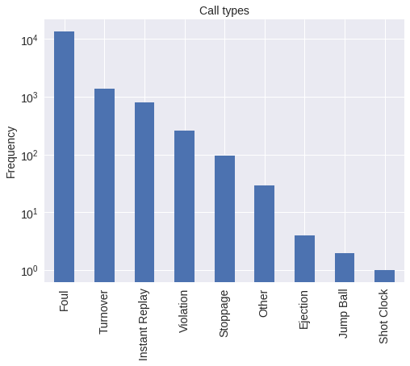

```python
(orig_df.call_type
        .str.split(':', expand=True).iloc[:, 0]
        .value_counts()
        .plot(kind='bar', color=blue, logy=True, title="Call types")
        .set_ylabel("Frequency"));
```

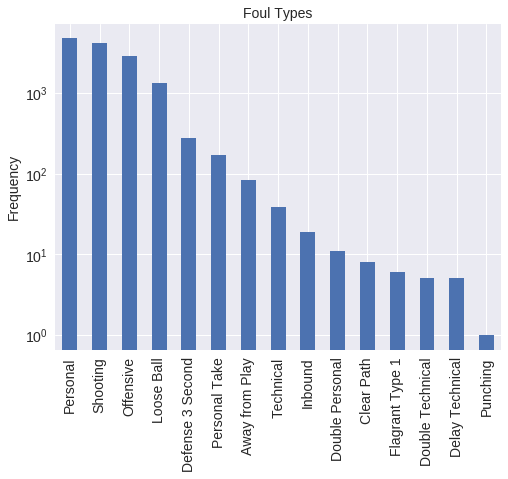

```python
(foul_df.call_type
        .str.split(': ', expand=True).iloc[:, 1]
        .value_counts()
        .plot(kind='bar', color=blue, logy=True, title="Foul Types")
        .set_ylabel("Frequency"));
```

### Data transformation

[figure not shown]

```python
df.head(n=2).T
```

| play_id | 20151028INDTOR-1 | 20151028INDTOR-2 |
| --- | --- | --- |
| seconds_left | 89.0 | 73.0 |
| call_type | 4.0 | 4.0 |
| foul_called | 1.0 | 0.0 |
| player_committing | 162.0 | 36.0 |
| player_disadvantaged | 98.0 | 358.0 |
| score_committing | 99.0 | 106.0 |
| score_disadvantaged | 106.0 | 99.0 |
| season | 0.0 | 0.0 |

## Modeling

[figure not shown]

George Box (via [Dustin Tran](http://dustintran.com/talks/Tran_Edward.pdf)):

1. Build a model of the science
2. Infer the model given data
3. Criticize the model given data

### Build a model of the science

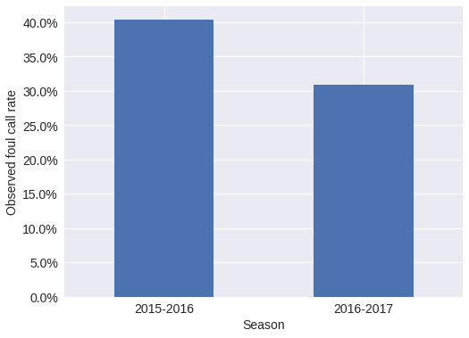

```python
make_foul_rate_yaxis(
    df.pivot_table('foul_called', 'season')
      .rename(index=season_enc.inverse_transform)
      .rename_axis("Season")
      .plot(kind='bar', rot=0, legend=False)
);
```

- Each season has a different foul call rate

```python
import pymc3 as pm

with pm.Model() as base_model:
    β_season = pm.Normal('β_season', 0., 5., shape=n_season)
    p = pm.Deterministic('p', pm.math.sigmoid(β_season))
```

- Foul calls are like flipping a weighted coin

```python
with base_model:
    y = pm.Bernoulli(
        'y', p[season],
        observed=df.foul_called.values
    )
```

### Infer the model given data

```python
with base_model:
    base_trace = pm.sample(**SAMPLE_KWARGS)
```

```
Auto-assigning NUTS sampler...
Initializing NUTS using jitter+adapt_diag...
```

#### Convergence diagnostics

> The folk theorem [of statistical computing] is this: When you have computational problems, often there’s a problem with your model.

— [Andrew Gelman](http://andrewgelman.com/2008/05/13/the_folk_theore/)

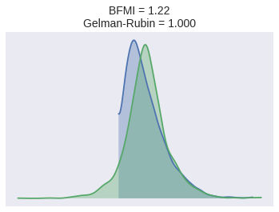

```python
(pm.energyplot(base_trace, legend=False, figsize=(6, 4))
   .set_title(CONVERGENCE_TITLE()));
```

### Criticize the model given data

```python
resid_df = (df.assign(p_hat=base_trace['p'][:, df.season].mean(axis=0))
              .assign(resid=lambda df: df.foul_called - df.p_hat))
```

```python
resid_df[['foul_called', 'p_hat', 'resid']].head()
```

| play_id | foul_called | p_hat | resid |
| --- | --- | --- | --- |
| 20151028INDTOR-1 | 1.0 | 0.403732 | 0.596268 |
| 20151028INDTOR-2 | 0.0 | 0.403732 | -0.403732 |
| 20151028INDTOR-3 | 1.0 | 0.403732 | 0.596268 |
| 20151028INDTOR-4 | 0.0 | 0.403732 | -0.403732 |
| 20151028INDTOR-6 | 0.0 | 0.403732 | -0.403732 |

```python
(resid_df.pivot_table('resid', 'season')
         .rename(index=season_enc.inverse_transform))
```

| season | resid |
| --- | --- |
| 2015-2016 | -0.000019 |
| 2016-2017 | 0.000026 |

#### Intentional fouls

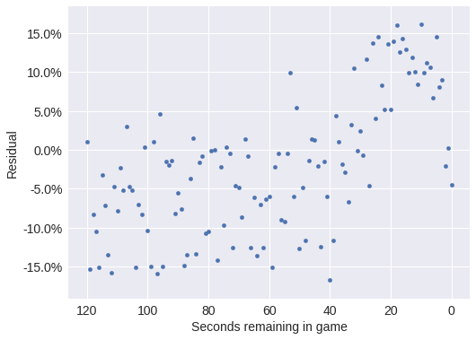

```python
make_time_axes(
    resid_df.pivot_table('resid', 'seconds_left')
            .reset_index()
            .plot('seconds_left', 'resid', kind='scatter'),
    ylabel="Residual"
);
```

### Build a model of the science, take two

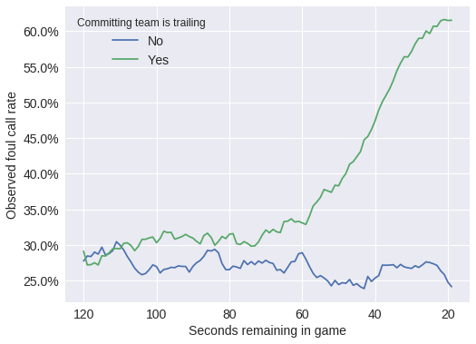

```python
make_time_axes(
    df.pivot_table('foul_called', 'seconds_left', 'trailing_committing')
      .rolling(20).mean()
      .rename(columns={0: "No", 1: "Yes"})
      .rename_axis("Committing team is trailing", axis=1)
      .plot()
);
```

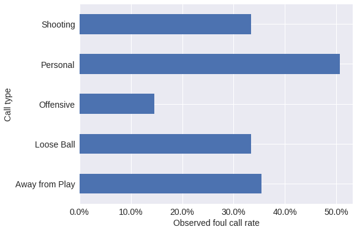

```python
ax = (df.pivot_table('foul_called', 'call_type')
        .rename(index=call_type_enc.inverse_transform)
        .rename_axis("Call type", axis=0)
        .plot(kind='barh', legend=False))
ax.xaxis.set_major_formatter(pct_formatter);
ax.set_xlabel("Observed foul call rate");
```

- Each call type has a different foul call rate

```python
with poss_model:
    β_call = hierarchical_normal('β_call', n_call_type)
```

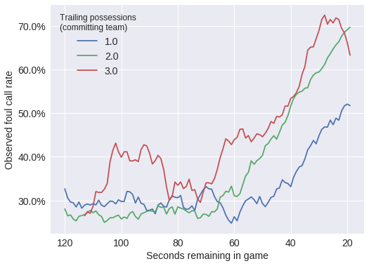

```python
make_time_axes(
    df.pivot_table('foul_called', 'seconds_left', 'trailing_poss')
      .loc[:, 1:3]
      .rolling(20).mean()
      .rename_axis(
          "Trailing possessions\n(committing team)",
          axis=1
      )
      .plot()
);
```

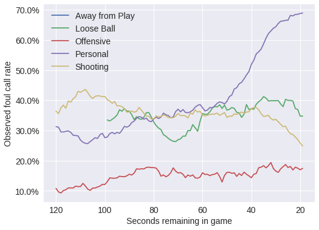

```python
make_time_axes(
    df.pivot_table('foul_called', 'seconds_left', 'call_type')
      .rolling(20).mean()
      .rename(columns=call_type_enc.inverse_transform)
      .rename_axis(None, axis=1)
      .plot()
);
```

#### The shot clock

[figure not shown]

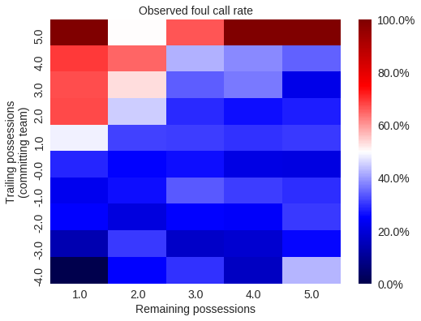

```python
ax = sns.heatmap(
    df.pivot_table('foul_called', 'trailing_poss', 'remaining_poss')
      .rename_axis(
          "Trailing possessions\n(committing team)", axis=0
      )
      .rename_axis("Remaining possessions", axis=1),
    cmap='seismic', cbar_kws={'format': pct_formatter}
)
ax.invert_yaxis();
ax.set_title("Observed foul call rate");
```

#### Difference from call type average

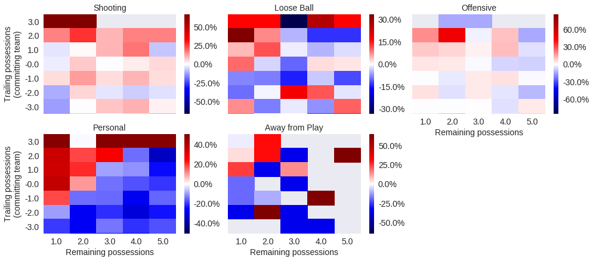

```python
(sns.FacetGrid(diff_df, col='call_type', col_wrap=3, aspect=1.5)
    .map_dataframe(plot_foul_diff_heatmap)
    .set_axis_labels(
        "Remaining possessions",
        "Trailing possessions\n(committing team)"
    )
    .set_titles("{col_name}"));
```

- The foul call rate changes based on the number of possessions trailing and remaining and the call type

```python
with poss_model:
    β_poss = hierarchical_normal(
        'β_poss',
        (n_trailing_poss, n_remaining_poss, n_call_type),
        σ_shape=(1, 1, n_call_type)
    )
```

- The foul call rate is a combination of season, call type, and possession factors

```python
with poss_model:
    η_game = β_season[season] \
                + β_call[call_type] \
                + β_poss[
                    trailing_poss, remaining_poss, call_type
                ]
```

### Infer the model given data, take two

```python
with poss_model:
    poss_trace = pm.sample(**SAMPLE_KWARGS)
```

```
Auto-assigning NUTS sampler...
Initializing NUTS using jitter+adapt_diag...
```

### Criticize the model given data, take two

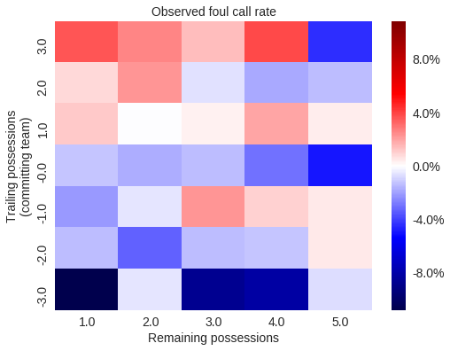

```python
ax = sns.heatmap(
    resid_df.pivot_table('resid', 'trailing_poss', 'remaining_poss')
      .rename_axis("Trailing possessions\n(committing team)", axis=0)
      .rename_axis("Remaining possessions", axis=1)
      .loc[-3:3],
    cmap='seismic',  cbar_kws={'format': pct_formatter}
)
ax.invert_yaxis();
ax.set_title("Observed foul call rate");
```

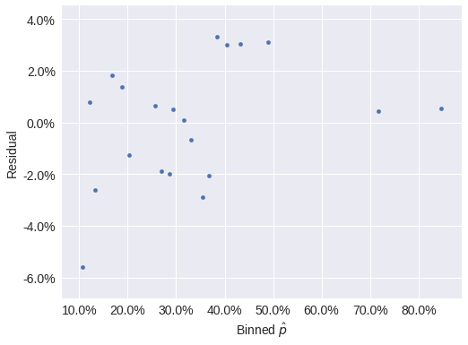

```python
ax = (resid_df.groupby(bins[bin_ix])
              .resid.mean()
              .rename_axis('p_hat', axis=0)
              .reset_index()
              .plot('p_hat', 'resid', kind='scatter'))

ax.xaxis.set_major_formatter(pct_formatter);
ax.set_xlabel(r"Binned $\hat{p}$");

make_foul_rate_yaxis(ax, label="Residual");
```

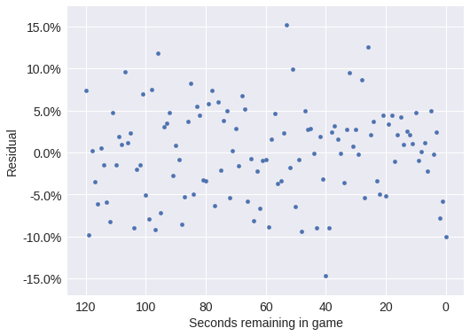

```python
ax = (resid_df.groupby('seconds_left')
              .resid.mean()
              .reset_index()
              .plot('seconds_left', 'resid', kind='scatter'))
make_time_axes(ax, ylabel="Residual");
```

#### Model selection

```python
comp_df = (pm.compare(
                (base_trace, poss_trace),
                (base_model, poss_model)
             )
             .rename(index=MODEL_NAME_MAP)
             .loc[MODEL_NAME_MAP.values()])
```

```python
comp_df
```

|  | WAIC | pWAIC | dWAIC | weight | SE | dSE | warning |
| --- | --- | --- | --- | --- | --- | --- | --- |
| Base | 11609.8 | 1.98 | 1543.34 | 0 | 56.98 | 73.35 | 1 |
| Possession | 10066.5 | 81.92 | 0 | 1 | 87.93 | 0 | 1 |

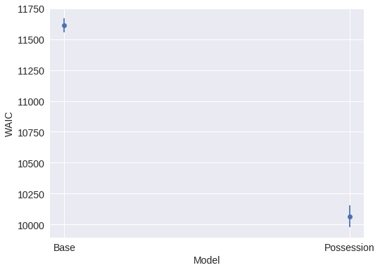

```python
fig, ax = plt.subplots()
ax.errorbar(
    np.arange(len(MODEL_NAME_MAP)), comp_df.WAIC,
    yerr=comp_df.SE, fmt='o'
);
ax.set_xticks(np.arange(len(MODEL_NAME_MAP)));
ax.set_xticklabels(comp_df.index);
ax.set_xlabel("Model");
ax.set_ylabel("WAIC");
```

### Research questions

1. How does game context impact foul calls?
2. Is (not) committing and/or drawing fouls a measurable player skill?

### Build a model of the science, take three

[figure not shown]

#### Item-response theory

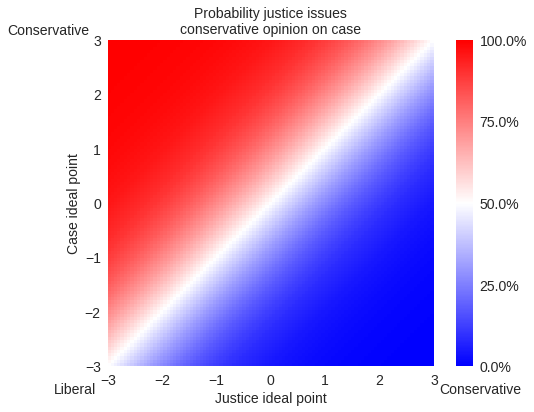

```python
fig
```

- Each disadvantaged player has an ideal point (per season)

```python
with irt_model:
    θ_player = hierarchical_normal(
        'θ_player', (n_player, n_season)
    )
    θ = θ_player[player_disadvantaged, season]
```

- Each committing player has an ideal point (per season)

```python
with irt_model:
    b_player = hierarchical_normal(
        'b_player', (n_player, n_season)
    )
    b = b_player[player_committing, season]
```

- Players affect the foul call rate through the difference in their ideal points

```python
with irt_model:
    η_player = θ - b
```

- Game and player effects combine to determine the foul call rate

```python
with irt_model:
    η = η_game + η_player
```

### Infer the model given data, take three

```python
with irt_model:
    irt_trace = pm.sample(**SAMPLE_KWARGS)
```

```
Auto-assigning NUTS sampler...
Initializing NUTS using jitter+adapt_diag...
```

### Criticize the model given data, take three

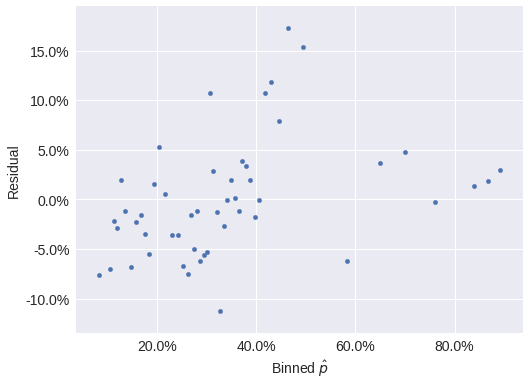

```python
ax = (resid_df.groupby(bins[bin_ix])
              .resid.mean()
              .rename_axis('p_hat', axis=0)
              .reset_index()
              .plot('p_hat', 'resid', kind='scatter'))
ax.xaxis.set_major_formatter(pct_formatter);
ax.set_xlabel(r"Binned $\hat{p}$");
make_foul_rate_yaxis(ax, label="Residual");
```

#### Model selection

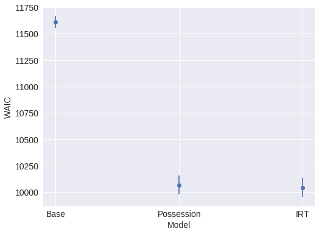

```python
fig, ax = plt.subplots()
ax.errorbar(
    np.arange(len(MODEL_NAME_MAP)), comp_df.WAIC,
    yerr=comp_df.SE, fmt='o'
);
ax.set_xticks(np.arange(len(MODEL_NAME_MAP)));
ax.set_xticklabels(comp_df.index);
ax.set_xlabel("Model");
ax.set_ylabel("WAIC");
```

#### Is committing and/or drawing fouls a measurable player skill?

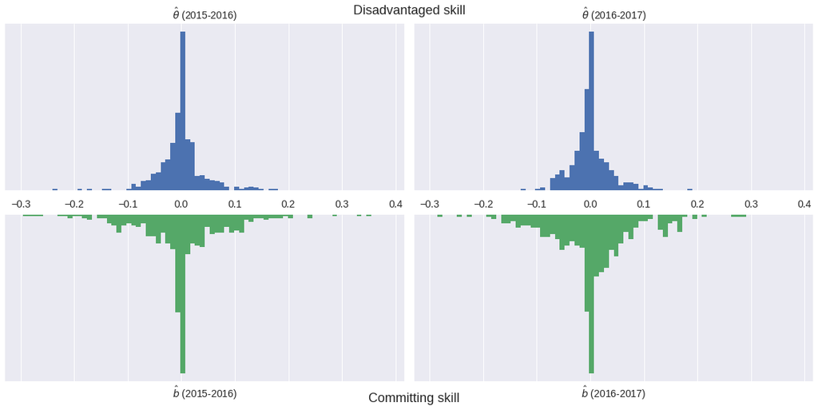

```python
fig
```

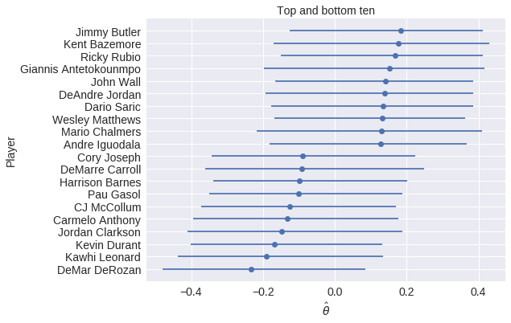

```python
fig, ax = plot_latent_params(
    top_bot_irt_df[top_bot_irt_df.param == 'θ']
                  .sort_values('mean')
)
ax.set_xlabel(r"$\hat{\theta}$");
ax.set_title("Top and bottom ten");
```

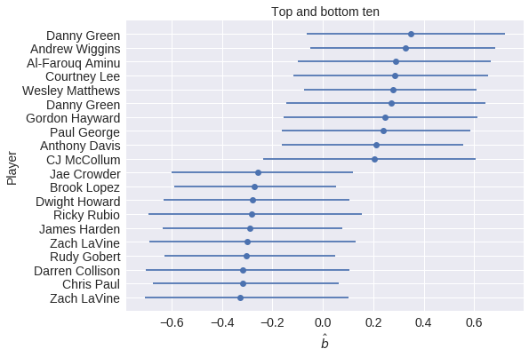

```python
fig, ax = plot_latent_params(
    top_bot_irt_df[top_bot_irt_df.param == 'b']
                  .sort_values('mean')
)
ax.set_xlabel(r"$\hat{b}$");
ax.set_title("Top and bottom ten");
```

```python
player_irt_df.head()
```

| param season player | b 0 | b 1 | θ 0 | θ 1 |
| --- | --- | --- | --- | --- |
| 0 | -0.064689 | 0.006621 | -0.015132 | -0.003946 |
| 1 | -0.006142 | 0.004387 | 0.010513 | 0.037012 |
| 2 | 0.090107 | 0.092868 | -0.034668 | -0.003519 |
| 3 | -0.022949 | -0.002456 | 0.005822 | -0.003961 |
| 4 | -0.006999 | 0.288897 | 0.068338 | 0.007508 |

##### Year-over-year consistency (players that appeared in all seasons)

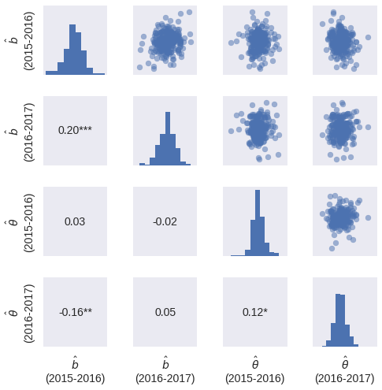

```python
style_grid(sns.PairGrid(player_irt_df.loc[player_all_season], size=1.75)
              .map_upper(plt.scatter, alpha=0.5)
              .map_diag(plt.hist)
              .map_lower(plot_corr));
```

##### Year-over-year consistency (players that appeared at least ten times in all seasons)

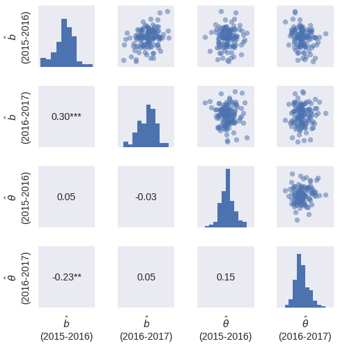

```python
grid.fig
```

### Research questions

1. How does game context impact foul calls?
2. Is (not) committing and/or drawing fouls a measurable player skill?

## Visualize the Predictions

```python
import dash
import dash_html_components as html
```

```python
app = dash.Dash()

app.layout = html.Div(children=[
    html.H1(
        "Understanding NBA Foul Calls with Python"
    ),
    html.Center(TABLE)
])
```

```python
@app.callback(
    dash.dependencies.Output(
        'irt-param-scatter', 'figure'
    ),
    [
        dash.dependencies.Input(
            'season-dropdown','value'
        ),
        dash.dependencies.Input(
            'player-committing-dropdown','value'
        ),
        dash.dependencies.Input(
            'player-disadvantaged-dropdown','value'
        )
    ]
)
def update_irt_scatter(season_,
                       player_committing_,
                       player_disadvantaged_):
    irt_df = get_irt_df(
        player_committing_=player_committing_,
        player_disadvantaged_=player_disadvantaged_,
        season_=season_,
    )

    return get_irt_scatter(irt_df)
```

## Thank You!

[figure not shown]

### [@AustinRochford](https://twitter.com/AustinRochford) • austinrochford.com • github.com/AustinRochford

### austin.rochford@gmail.com • arochford@monetate.com